# Amazon Forecast: predicting time-series at scale

Forecasting is used in a variety of applications and business use cases: For example, retailers need to forecast the sales of their products to decide how much stock they need by location, Manufacturers need to estimate the number of parts required at their factories to optimize their supply chain, Businesses need to estimate their flexible workforce needs, Utilities need to forecast electricity consumption needs in order to attain an efficient energy network, and enterprises need to estimate their cloud infrastructure needs.

[figure not shown]

- Problem Description
- Step 0: Setting up
- Step 1: Preparing the Datasets
- Step 2: Importing the Data
  - Step 2a: Creating a Dataset Group
  - Step 2b: Creating a Target Dataset
  - Step 2c: Creating a Related Dataset
  - Step 2d: Update the Dataset Group
  - Step 2e: Creating a Target Time Series Dataset Import Job
  - Step 2f: Creating a Related Time Series Dataset Import Job
- Step 3: Choosing an Algorithm and Evaluating its Performance
  - Step 3a: Choosing Prophet
  - Step 3b: Choosing DeepAR+
- Step 4: Computing Error Metrics from Backtesting
- Step 5: Creating a Forecast
- Step 6: Querying the Forecasts
- Step 7: Exporting the Forecasts
- Step 8: Clearning up your Resources

# Problem: Forecasting Bicycle Sales

In this notebook, we will use Amazon Forecast to predict hourly bicycle sales using a sample retail data set that contains hostorical data for the quantity of bicycles sold each hour. The data starts in 2011, and contains for many different bicycles. This is a typical retail forecasting problem, where the volume of projected sales is important to optimize inventory, determine workforce demand and project daily sales.

[figure not shown]

# First setup Amazon Forecast

This section sets up the permissions and relevant endpoints. This notebook is using Python and the AWS python library called boto3. You can also accomplish many of the task using the console directly. The first step in a Python script is to import all the required libraries, which we do below.

> **NOTE:** Be sure you are using Jupyter Notebooks NOT Jupyter Lab as there are incompatabilities with it. Also be sure to disable add blockers. Also use a modern browser.

```python
# import boto3 and json libs
import warnings, boto3, json

# import custom libs from local directory
from util.fcst_utils import *
from util.hint import hint

# set the size of generated graphs
plt.rcParams['figure.figsize'] = (15.0, 5.0)
warnings.filterwarnings('ignore')
```

Now we wil create a boto3 session. Boto3 allows us to interact with all of the AWS services via python. The region for the session is the defaulted region for your account. You can choose any of the 6 regions where the forecast service is available.

Once we have the boto3 session, we csan create the clients for forecast and forecast query.

```python
# get boto3 session and s3 client
session = boto3.Session()  # can specify region here i.e. region='us-west-2'

# get the s3, forecast and forecast-query clients
forecast = session.client('forecast')
forecast_query = session.client('forecastquery')
```

We also need the some resources. The role arn determines permissions when creating various forecast entities. The unique s3 bucket where all our forecast data will be stored is also neede. We also need a project prefix for all the forecast entities we will be creating, so they are easier to find.

```python
role_arn = get_or_create_role_arn()
account_id = session.client('sts').get_caller_identity().get('Account')

# set bucket name and key
project = "forecastworkshop"
bucket_name = f"{project}{account_id}"
s3_data_path = f"s3://{bucket_name}/data"
```

```
arn:aws:iam::856026949073:role/AmazonForecastWorkshopRole
```

Finally, we need the parameters that we will pass to the Forecast service that determine how to process the time series data. The forecast horizon is how far into the future we wich to forecast. This will be explained in greater detail below.

```python
timeseries_frequency = "H" # hourly frequency data
forecast_horizon = 24  # forecast 24 hours into future
timestamp_format = "yyyy-MM-dd HH:mm:ss" # timestamp format
```

# Overview

Now that we have the libs and settings done, lets review what the end to end process is to create forecasts. The process is broken into three main steps. First we import data, then we train a predictor, and finally we generate forecasts. Once forecasts have been generated, they can then be queried via an API call, or retrieved in batch.

[figure not shown]

# Step 1: Preparing the Datasets

Prior to importing into Amazon Forecast, we need to prepare the bicycle dataset. In a production environment, this wlogic ould be called as a script in you data piepline project. For larger datasets typical to Timeseries forecasting, this data preparations step may need to be a Glue or EMR job that take advatage of distributed computing for data processing. This is outside the scope of this tutorial, but here is a blog post on [how to extract transform and load data for analytic processing using aws glue](https://aws.amazon.com/blogs/database/how-to-extract-transform-and-load-data-for-analytic-processing-using-aws-glue-part-2/) that you may find useful in the future.

For this workshop we will use pandas, a python library used for processing data in memory. The first step is to read a local csv into a Dataframe, a data structure similar to a table.

```python
# read the data
bike_df = pd.read_csv("../data/train.csv", dtype = object)

# print the first 4 rows
bike_df.head()
```

|  | datetime | season | holiday | workingday | weather | temp | atemp | humidity | windspeed | casual | registered | count |
| --- | --- | --- | --- | --- | --- | --- | --- | --- | --- | --- | --- | --- |
| 0 | 2011-01-01 00:00:00 | 1 | 0 | 0 | 1 | 9.84 | 14.395 | 81 | 0 | 3 | 13 | 16 |
| 1 | 2011-01-01 01:00:00 | 1 | 0 | 0 | 1 | 9.02 | 13.635 | 80 | 0 | 8 | 32 | 40 |
| 2 | 2011-01-01 02:00:00 | 1 | 0 | 0 | 1 | 9.02 | 13.635 | 80 | 0 | 5 | 27 | 32 |
| 3 | 2011-01-01 03:00:00 | 1 | 0 | 0 | 1 | 9.84 | 14.395 | 75 | 0 | 3 | 10 | 13 |
| 4 | 2011-01-01 04:00:00 | 1 | 0 | 0 | 1 | 9.84 | 14.395 | 75 | 0 | 0 | 1 | 1 |

```python
# do conversion of data read so it is the right type
bike_df['count'] = bike_df['count'].astype('float')
bike_df['workingday'] = bike_df['workingday'].astype('float')
```

We take about two and a half week's of hourly data for demonstration, just for the purpose that there's no missing data in the whole range. Using the pandas slice operator `:` we select this time period of data. `-` indexes in a slice operator signify the number of entries away from the end. Once we have the selected rows of data, we select only rows for a single type of bike, `bike_12`.

```python
last_two_and_half_weeks_in_hours = 2*7*24+24*3 # 2 weeks and 3 days in hours
bike_df_small = bike_df[-last_two_and_half_weeks_in_hours:] # negative index in a slice counts from end of list
bike_df_small['item_id'] = "bike_12"
```

Now we can plot the count of sales of bike_12 bikes over time on an hourly basis.

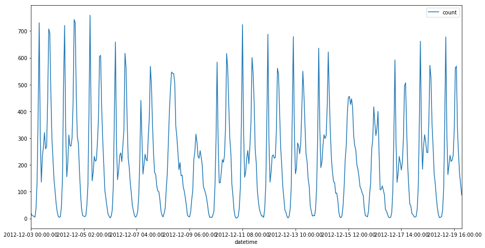

```python
bike_df_small.plot(x='datetime', y='count', figsize=(15, 8))
```

We can see that the target time series seem to have a drop over weekends. Next let's plot both the target time series and the related time series that indicates whether today is a `workday` or not. More precisely, $r_t = 1$ if $t$ is a work day and 0 if not.

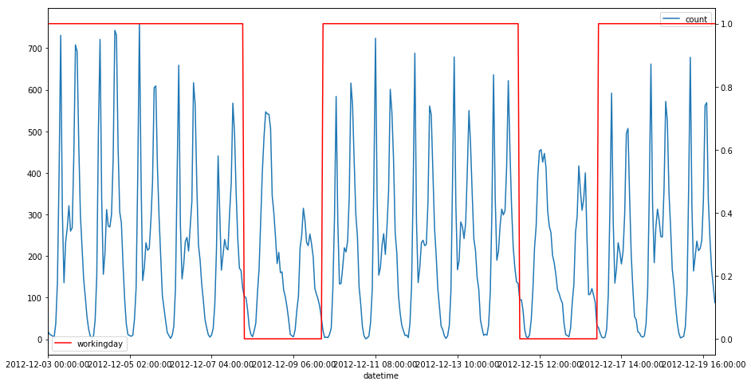

```python
plt.figure(figsize=(15, 8))
ax = plt.gca()
bike_df_small.plot(x='datetime', y='count', ax=ax);
ax2 = ax.twinx()
bike_df_small.plot(x='datetime', y='workingday', color='red', ax=ax2);
```

To use the related time series, we need to ensure that the related time series covers the whole target time series, as well as the future values as specified by the forecast horizon. More precisely, we need to make sure:

```
len(related time series) >= len(target time series) + forecast horizon
```

Basically, all items need to have data start at or before the item start date, and have data until the forecast horizon (i.e. the latest end date across all items + forecast horizon). Additionally, there should be no missing values in the related time series. The following picture illustrates the desired logic.

[figure not shown]

For more details regarding how to prepare your Related Time Series dataset, please refer to the public documentation [here](https://docs.aws.amazon.com/forecast/latest/dg/related-time-series-datasets.html).

Suppose in this particular example, we wish to forecast for the next 24 hours, and thus we generate the following dataset.

```python
target_df = bike_df_small[['item_id', 'datetime', 'count']][:-24]
related_df = bike_df_small[['item_id', 'datetime', 'workingday']]
```

```python
target_df.head(5)
```

|  | item_id | datetime | count |
| --- | --- | --- | --- |
| 10478 | bike_12 | 2012-12-03 00:00:00 | 21.0 |
| 10479 | bike_12 | 2012-12-03 01:00:00 | 13.0 |
| 10480 | bike_12 | 2012-12-03 02:00:00 | 10.0 |
| 10481 | bike_12 | 2012-12-03 03:00:00 | 8.0 |
| 10482 | bike_12 | 2012-12-03 04:00:00 | 5.0 |

As we can see, the length of the related time series is equal to the length of the target time series plus the forecast horizon.

```python
print(len(target_df), len(related_df))
assert len(target_df) + 24 == len(related_df), "length doesn't match"
```

```
384 408
```

Next we check whether there are "holes" in the related time series.

```python
assert len(related_df) == len(pd.date_range(
    start=list(related_df['datetime'])[0],
    end=list(related_df['datetime'])[-1],
    freq=timeseries_frequency
)), "missing entries in the related time series"
```

Everything looks fine, and we plot both time series again. As it can be seen, the related time series (indicator of whether the current day is a workday or not) is longer than the target time series. The binary working day indicator feature is a good example of a related time series, since it is known at all future time points. Other examples of related time series include holiday and promotion features.

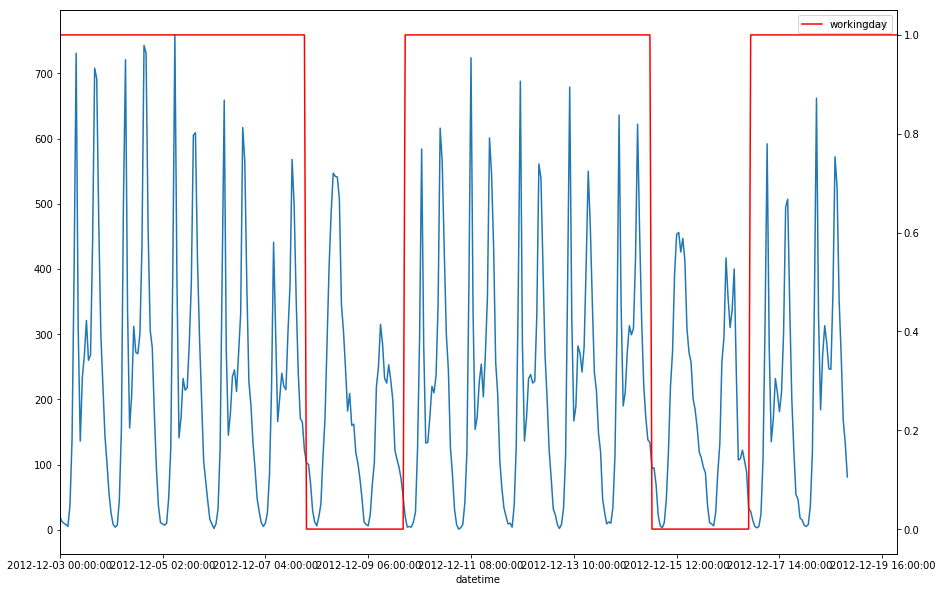

```python
plt.figure(figsize=(15, 10))
ax = plt.gca()
target_df.plot(x='datetime', y='count', ax=ax);
ax2 = ax.twinx()
related_df.plot(x='datetime', y='workingday', color='red', ax=ax2);
```

```python
target_df.to_csv("../data/bike_target.csv", index= False, header = False)
related_df.to_csv("../data/bike_related.csv", index= False, header = False)
```

The bucket `forecastworkshop{account_id}`, should have been created already in S3. The calls below will create it if it doesnt exist, and then syncronise the data we created to the bucket.

> **NOTE:** Ignore any warning or error below that complains about the bucket already existing.

```python
# sync data to s3
# '!' is used to make calls to the os shell
# where we then us the aws command line
!aws s3 mb s3://$bucket_name
!aws s3 sync ../data $s3_data_path
```

```
make_bucket: forecastworkshop856026949073
upload: ../data/bike_related.csv to s3://forecastworkshop856026949073/data/bike_related.csv
upload: ../data/bike_target.csv to s3://forecastworkshop856026949073/data/bike_target.csv
upload: ../data/cold-start/itemMetaData.csv to s3://forecastworkshop856026949073/data/cold-start/itemMetaData.csv
upload: ../data/item-meta.csv to s3://forecastworkshop856026949073/data/item-meta.csv
upload: ../data/cold-start/coldStartTargetData.csv to s3://forecastworkshop856026949073/data/cold-start/coldStartTargetData.csv
upload: ../data/item-demand-time-train.csv to s3://forecastworkshop856026949073/data/item-demand-time-train.csv
upload: ../data/bike.csv to s3://forecastworkshop856026949073/data/bike.csv
upload: ../data/test.csv to s3://forecastworkshop856026949073/data/test.csv
upload: ../data/train.csv to s3://forecastworkshop856026949073/data/train.csv
upload: ../data/item-demand-time.csv to s3://forecastworkshop856026949073/data/item-demand-time.csv
upload: ../data/item-demand-time-validation.csv to s3://forecastworkshop856026949073/data/item-demand-time-validation.csv
upload: ../data/cold-start/test.csv.gz to s3://forecastworkshop856026949073/data/cold-start/test.csv.gz
```

# Step 2. Importing the Data

To train a predictor, you create one or more datasets, add them to a dataset group, and provide the dataset group for training.

For each dataset that you create, you associate a dataset domain and a dataset type. A dataset domain defines a forecasting use case. Each domain can have one to three dataset types. The dataset types that you create for a domain are based on the type of data that you have and what you want to include in training.

Each domain requires a **TARGET_TIME_SERIES** dataset, and optionally supports the RELATED_TIME_SERIES and ITEM_METADATA dataset types.

The dataset types are:

**TARGET_TIME_SERIES** The only required dataset type. This type defines the target field that you want to generate forecasts for. For example, if you want to forecast the sales for a set of products, then you must create a dataset of historical time-series data for each of the products that you want to forecast. Similarly, you can create a target_time_series dataset for metrics— such as revenue, cash flow, and sales—that you might want to forecast.

**RELATED_TIME_SERIES** Time-series data that is related to the target time-series data. For example, price is related to product sales data, so you might provide it as a related_time_series.

**ITEM_METADATA** Metadata that is applicable to the target time-series data. For example, if you are forecasting sales for a particular product, attributes of the product—such as brand, color, and genre—will be part of item_metadata. When predicting EC2 capacity for EC2 instances, metadata might include the CPU and memory of the instance types.

For each dataset type, your input data must contain certain required fields. You can also include optional fields that Amazon Forecast suggests that you include.

For this workshop we will be working with a **RETAIL** use case for bike sales. An example dataset for a retailer normally records the transaction record like this:

[figure not shown]

We will be doing the data import via a series of python calls to the forecast service, but you could also do this directly from the aws console.

[figure not shown]

## Step 2a. Creating a Dataset Group

First let's create a dataset group and then update it later to add our datasets. Since this is a **RETAIL** use case we will specify that as the domain.

```python
dataset_group = f"{project}_dataset_group"
print(dataset_group)
create_dataset_group_response = forecast.create_dataset_group(Domain="RETAIL",
                                                          DatasetGroupName=dataset_group,
                                                          DatasetArns=[])

dataset_group_arn = create_dataset_group_response['DatasetGroupArn']

forecast.describe_dataset_group(DatasetGroupArn=dataset_group_arn)
```

```
forecastworkshop_dataset_group
```

```
{'DatasetGroupName': 'forecastworkshop_dataset_group',
 'DatasetGroupArn': 'arn:aws:forecast:us-west-2:856026949073:dataset-group/forecastworkshop_dataset_group',
 'DatasetArns': [],
 'Domain': 'RETAIL',
 'Status': 'ACTIVE',
 'CreationTime': datetime.datetime(2019, 12, 2, 21, 22, 0, 593000, tzinfo=tzlocal()),
 'LastModificationTime': datetime.datetime(2019, 12, 2, 21, 22, 0, 593000, tzinfo=tzlocal()),
 'ResponseMetadata': {'RequestId': '5129f1f2-4455-489e-84db-b38afbcbc17e',
  'HTTPStatusCode': 200,
  'HTTPHeaders': {'content-type': 'application/x-amz-json-1.1',
   'date': 'Mon, 02 Dec 2019 21:22:00 GMT',
   'x-amzn-requestid': '5129f1f2-4455-489e-84db-b38afbcbc17e',
   'content-length': '283',
   'connection': 'keep-alive'},
  'RetryAttempts': 0}}
```

## Step 2b. Creating a Target Dataset

Now we will define a target time series. This is a required dataset to use the service. For this exmaple, the number of items sold, or `demand` is the target value we will be forecasting.

First, we specify the name and schema of our dataset. Make sure the order of the attributes (columns) matches the raw data in the files. We follow the same three attribute format as the above example.

```python
name = f"{project}_target_dataset"
schema = {
    "Attributes": [
        {
            "AttributeName": "item_id",
            "AttributeType": "string"
        },
        {
            "AttributeName": "timestamp",
            "AttributeType": "timestamp"
        },
        {
            "AttributeName": "demand",
            "AttributeType": "float"
        }
    ]
}
```

Now that we have a schema and name we can create the target data set. This only sets up the definition of the dataset. No data has been imported to Forecast yet. Data import will happen later when we create the import jobs.

```python
response = forecast.create_dataset(Domain="RETAIL",
                               DatasetType='TARGET_TIME_SERIES',
                               DatasetName=name,
                               DataFrequency=timeseries_frequency,
                               Schema=schema
)

target_dataset_arn = response['DatasetArn']
forecast.describe_dataset(DatasetArn=target_dataset_arn)
```

```
{'DatasetArn': 'arn:aws:forecast:us-west-2:856026949073:dataset/forecastworkshop_target_dataset',
 'DatasetName': 'forecastworkshop_target_dataset',
 'Domain': 'RETAIL',
 'DatasetType': 'TARGET_TIME_SERIES',
 'DataFrequency': 'H',
 'Schema': {'Attributes': [{'AttributeName': 'item_id',
    'AttributeType': 'string'},
   {'AttributeName': 'timestamp', 'AttributeType': 'timestamp'},
   {'AttributeName': 'demand', 'AttributeType': 'float'}]},
 'EncryptionConfig': {},
 'Status': 'ACTIVE',
 'CreationTime': datetime.datetime(2019, 12, 2, 21, 22, 0, 699000, tzinfo=tzlocal()),
 'LastModificationTime': datetime.datetime(2019, 12, 2, 21, 22, 0, 699000, tzinfo=tzlocal()),
 'ResponseMetadata': {'RequestId': '8e1afd7c-8405-42b1-aea1-8c6633f14dda',
  'HTTPStatusCode': 200,
  'HTTPHeaders': {'content-type': 'application/x-amz-json-1.1',
   'date': 'Mon, 02 Dec 2019 21:22:00 GMT',
   'x-amzn-requestid': '8e1afd7c-8405-42b1-aea1-8c6633f14dda',
   'content-length': '517',
   'connection': 'keep-alive'},
  'RetryAttempts': 0}}
```

## Step 2c. (OPTIONAL) Creating a Related Dataset

Now we will create a related time series dataset using the workingday flag. The method call is very simliar to the target time series, except you will have `workingday` instead of `demand`.

> **NOTE:** The hint button is here to help you! If you have trouble completing the code, click the button and the code will be revealed line by line.

```python
hint('2c')
```

```python
related_dataset_arn = None

name = f"{project}_related_dataset"
#schema =
#response =
#related_dataset_arn =
#forecast.describe_dataset(DatasetArn=related_dataset_arn)
```

## Step 2d. Updating the dataset group with the datasets we created

You can have multiple datasets under the same dataset group. Update it with the datasets we created before.

```python
dataset_arns = [target_dataset_arn]
if related_dataset_arn:
    dataset_arns.append(related_dataset_arn)

forecast.update_dataset_group(DatasetGroupArn=dataset_group_arn, DatasetArns=dataset_arns)
forecast.describe_dataset_group(DatasetGroupArn=dataset_group_arn)
```

```
{'DatasetGroupName': 'forecastworkshop_dataset_group',
 'DatasetGroupArn': 'arn:aws:forecast:us-west-2:856026949073:dataset-group/forecastworkshop_dataset_group',
 'DatasetArns': ['arn:aws:forecast:us-west-2:856026949073:dataset/forecastworkshop_target_dataset'],
 'Domain': 'RETAIL',
 'Status': 'ACTIVE',
 'CreationTime': datetime.datetime(2019, 12, 2, 21, 22, 0, 593000, tzinfo=tzlocal()),
 'LastModificationTime': datetime.datetime(2019, 12, 2, 21, 22, 0, 901000, tzinfo=tzlocal()),
 'ResponseMetadata': {'RequestId': '5271c757-362b-43cb-9f7d-e8bd4055f129',
  'HTTPStatusCode': 200,
  'HTTPHeaders': {'content-type': 'application/x-amz-json-1.1',
   'date': 'Mon, 02 Dec 2019 21:22:00 GMT',
   'x-amzn-requestid': '5271c757-362b-43cb-9f7d-e8bd4055f129',
   'content-length': '364',
   'connection': 'keep-alive'},
  'RetryAttempts': 0}}
```

## Step 2e. Creating a Target Time Series Dataset Import Job

Now that we that we have defined the target time series, will still need to create an import job to actually load the data into Amazon Forecast from s3.

```python
s3_path = f"{s3_data_path}/bike_target.csv"

response = forecast.create_dataset_import_job(
    DatasetImportJobName=dataset_group,
    DatasetArn=target_dataset_arn,
    DataSource= {
        "S3Config" : {
            "Path": s3_path,
            "RoleArn": role_arn
        }
    },
    TimestampFormat= timestamp_format
)

target_dataset_import_job_arn = response['DatasetImportJobArn']
```

## Step 2f. (OPTIONAL) Creating a Related Time Series Dataset Import Job

If you have time, try to create a related time series import job. Don't worry if you dont complete this section, you will still be able to complete the workshop without it.

```python
hint('2f')
```

```python
related_dataset_import_job_arn = None

#s3_path = f"{s3_data_path}/bike_related.csv"
# TODO
#related_dataset_import_job_arn = response['DatasetImportJobArn']
```

We now need to wait for all the import jobs to finish. We will use a simple blocking `wait` method that checks the import job status.

```python
assert(wait(lambda: forecast.describe_dataset_import_job(DatasetImportJobArn=target_dataset_import_job_arn)))

if related_dataset_import_job_arn:
    assert(wait(lambda: forecast.describe_dataset_import_job(DatasetImportJobArn=related_dataset_import_job_arn)))
```

[output not shown]

You can now go to the [Amazon Forecast console](https://us-west-2.console.aws.amazon.com/forecast/home?region=us-west-2#datasetGroups) and see your import jobs running.

# Step 3. Choosing an Algorithm

Once the datasets are specified with the corresponding schema, Amazon Forecast will automatically aggregate all the relevant pieces of information for each item, such as sales, price, promotions, as well as categorical attributes, and generate the desired dataset. Next, one can choose an algorithm (forecasting model) and evaluate how well this particular algorithm works on this dataset. The following graph gives a high-level overview of the forecasting models.

[figure not shown]

Amazon Forecast provides several state-of-the-art forecasting algorithms including classic forecasting methods such as ETS, ARIMA, Prophet and deep learning approaches such as DeepAR+. Classical forecasting methods, such as Autoregressive Integrated Moving Average (ARIMA) or Exponential Smoothing (ETS), fit a single model to each individual time series, and then use that model to extrapolate the time series into the future. Amazon's Non-Parametric Time Series (NPTS) forecaster also fits a single model to each individual time series. Unlike the naive or seasonal naive forecasters that use a fixed time index (the previous index $T-1$ or the past season $T - \tau$) as the prediction for time step $T$, NPTS randomly samples a time index $t \in \{0, \dots T-1\}$ in the past to generate a sample for the current time step $T$.

In many applications, you may encounter many similar time series across a set of cross-sectional units. Examples of such time series groupings are demand for different products, server loads, and requests for web pages. In this case, it can be beneficial to train a single model jointly over all of these time series. DeepAR+ takes this approach, outperforming the standard ARIMA and ETS methods when your dataset contains hundreds of related time series. The trained model can also be used for generating forecasts for new time series that are similar to the ones it has been trained on. While deep learning approaches can outperform standard methods, this is only possible when there is sufficient data available for training. It is not true for example when one trains a neural network with a time-series contains only a few dozens of observations. Amazon Forecast provides the best of two worlds allowing users to either choose a specific algorithm or let Amazon Forecast automatically perform model selection.

```python
base_algorithm_arn = 'arn:aws:forecast:::algorithm/'
```

## Step 3a. Choosing Prophet

Prophet is a popular local Bayesian structural time series model. The Amazon Forecast Prophet algorithm uses the Prophet class of the Python implementation of Prophet.

#### How Prophet Works

Prophet is especially useful for datasets that:

- Contain an extended time period (months or years) of detailed historical observations (hourly, daily, or weekly)
- Have multiple strong seasonalities
- Include previously known important, but irregular, events
- Have missing data points or large outliers
- Have non-linear growth trends that are approaching a limit

Prophet is an additive regression model with a piecewise linear or logistic growth curve trend. It includes a yearly seasonal component modeled using Fourier series and a weekly seasonal component modeled using dummy variables.

For more information, see the [Amazon Forecast Documentation](https://docs.aws.amazon.com/forecast/latest/dg/aws-forecast-recipe-prophet.html).

Prophet Hyperparameters and Related Time Series Amazon Forecast uses the default Prophet hyperparameters. Prophet also supports related time-series as features, provided to Amazon Forecast in the related time-series CSV file.

```python
algorithm_arn = f'{base_algorithm_arn}Prophet'
predictor_name = f'{project}_Prophet'

response = forecast.create_predictor(
    PredictorName = predictor_name,
    AlgorithmArn = algorithm_arn,
    ForecastHorizon = forecast_horizon,
    PerformAutoML = False,
    PerformHPO = False,
    InputDataConfig = {'DatasetGroupArn': dataset_group_arn},
    FeaturizationConfig = {'ForecastFrequency': timeseries_frequency}
)

predictor_arn_prophet = response['PredictorArn']
```

[output not shown]

## Step 3b. (OPTIONAL) Choosing DeepAR+

Amazon Forecast DeepAR+ is a supervised learning algorithm for forecasting scalar (one-dimensional) time series using recurrent neural networks (RNNs). Classical forecasting methods, such as autoregressive integrated moving average (ARIMA) or exponential smoothing (ETS), fit a single model to each individual time series, and then use that model to extrapolate the time series into the future. In many applications, however, you have many similar time series across a set of cross-sectional units. These time-series groupings demand different products, server loads, and requests for web pages. In this case, it can be beneficial to train a single model jointly over all of the time series. DeepAR+ takes this approach. When your dataset contains hundreds of feature time series, the DeepAR+ algorithm outperforms the standard ARIMA and ETS methods. You can also use the trained model for generating forecasts for new time series that are similar to the ones it has been trained on.

For more on DeepAR+, see the [Amazon Forecast Doumentation](https://docs.aws.amazon.com/forecast/latest/dg/aws-forecast-recipe-deeparplus.html).

```python
hint('3b')
```

```python
predictor_arn_deep_ar = None
#algorithm_arn = f'{base_algorithm_arn}Deep_AR_Plus'
#predictor_name = f'{project}_Deep_AR_Pls'
# TODO
# predictor_arn_deep_ar = response['PredictorArn']
```

### Optional: Want to try another Predictor?

If you would like to try different predictors, check out the [Amazon Forecast Documentation](https://docs.aws.amazon.com/forecast/latest/dg/aws-forecast-choosing-recipes.html), and create another predictor.

```python
predictor_arn_other=None

#algorithm_arn = f'{base_algorithm_arn}##TODO##'
#predictor_name = f'{project}_##TODO##'

#response = #TODO

#predictor_arn_other = create_predictor_response['PredictorArn']
```

We now need to wait for all predictors to complete training.

```python
wait(lambda: forecast.describe_predictor(PredictorArn=predictor_arn_prophet))
forecast.describe_predictor(PredictorArn=predictor_arn_prophet)

if predictor_arn_other:
    wait(lambda: forecast.describe_predictor(PredictorArn=predictor_arn_other))
    forecast.describe_predictor(PredictorArn=predictor_arn_other)

if predictor_arn_deep_ar:
    wait(lambda: forecast.describe_predictor(PredictorArn=predictor_arn_deep_ar))
    forecast.describe_predictor(PredictorArn=predictor_arn_deep_ar)
```

[output not shown]

# Step 4. Computing Error Metrics from Backtesting

### How to evaluate a forecasting model?

To evaluate the accuracy of an algorithm for various forecasting scenarios and to tune the predictor, use predictor metrics. Amazon Forecast uses backtesting to produce metrics.

Forecast automatically splits your input data into two datasets, training and test, as shown in the following figure. Forecast decides how to split the input data by using the BackTestWindowOffset parameter that you specify in the CreatePredictor operation, or if not specified, it uses the default value of the ForecastHorizon parameter. For more information, see EvaluationParameters.

[figure not shown]

To evaluate the metrics in multiple backtest scenarios with different virtual forecast start dates, as shown in the following figure, use the NumberOfBacktestWindows parameter in the `CreatePredictor` operation. The default for the `NumberOfBacktestWindows` parameter is 1. If you use the default, Forecast uses the simple splitting method shown in the preceding figure.

[figure not shown]

After training, Amazon Forecast calculates the root mean square error (RMSE) and weighted quantile losses to determine how well the model predicted the test data in each backtest window and the average value over all the backtest windows. These metrics measure the difference between the values predicted by the model and the actual values in the test dataset. To retrieve the metrics, you use the `GetAccuracyMetrics` operation.

#### Prediction Quantiles and MAPE

Prediction quantiles (intervals) express the uncertainty in the forecasts. By calculating prediction quantiles, the model shows how much uncertainty is associated with each forecast. Without accompanying prediction quantiles, point forecasts have limited value.

Predicting forecasts at different quantiles is particularly useful when the costs of under and over predicting differ. Amazon Forecast provides probabilistic predictions at three distinct quantiles—10%, 50%, and 90%—and calculates the associated loss (error) at each quantile. The weighted quantile loss (wQuantileLoss) calculates how far off the forecast is from actual demand in either direction. This is calculated as a percentage of demand on average in each quantile. This metric helps capture the bias inherent in each quantile, which can't be captured by a calculation like MAPE (Mean Absolute Percentage Error), where the weights are equal. As with MAPE and RMSE, lower wQuantileLoss errors indicate better overall forecast accuracy.

Amazon Forecast calculates the weighted P10, P50, and P90 quantile losses, where τ is in the set {0.1, 0.5, 0.9}, respectively. This covers the standard 80% confidence interval. For RMSE, Amazon Forecast uses the P50 forecast to represent the predicted value, for example, ŷi,t = qi,t(0.5).

When the sum of the exact target over all items and all time is approximately zero in a given backtest window, the weighted quantile loss expression is undefined. In this case, Amazon Forecast outputs the unweighted quantile loss, which is the numerator in the above wQuantileLoss expression.

**wQuantileLoss[0.1]**: For the P10 prediction, the true value is expected to be lower than the predicted value 10% of the time.

For example, suppose that you're a retailer and you want to forecast product demand for winter gloves that sell well only during the fall and winter. If you don't have a lot of storage space and the cost of invested capital is high, or if the price of being overstocked on winter gloves concerns you, you might use the P10 quantile to order a relatively low number of winter gloves. You know that the P10 forecast overestimates the demand for your winter gloves only 10% of the time, so 90% of the time you'll be sold out of your winter gloves.

**wQuantileLoss[0.5]**: For the P50 prediction, the true value is expected to be lower than the predicted value 50% of the time. In most cases, the point forecasts that you generate internally or with other forecasting tools should match the P50 forecasts.

**wQuantileLoss[0.9]**: For the P90 prediction, the true value is expected to be lower than the predicted value 90% of the time.

If you determine that being understocked on gloves will result in huge amounts of lost revenue—for example, the cost of not selling gloves is extremely high or the cost of invested capital is low—you might choose to use the P90 quantile to order gloves.

The following figure of a forecast that has a Gaussian distribution, shows the quantiles that divide the forecast into four regions of equal probability. For information about the quantiles of a distribution, see Quantile on Wikipedia.

[figure not shown]

### Get the Error Metrics

Now that we have trained predictors, we can get the error metrics for them.

```python
predictor_arn_deep_ar = None
```

```python
error_metrics_prophet = forecast.get_accuracy_metrics(PredictorArn=predictor_arn_prophet)
print(error_metrics_prophet)

if predictor_arn_deep_ar is not None:
    error_metrics_deep_ar_plus = forecast.get_accuracy_metrics(PredictorArn=predictor_arn_deep_ar)
    print(error_metrics_deep_ar_plus)

if predictor_arn_other:
    error_metrics_other = forecast.get_accuracy_metrics(PredictorArn=predictor_arn_other)
    print(error_metrics_other)
```

```
{'PredictorEvaluationResults': [{'AlgorithmArn': 'arn:aws:forecast:::algorithm/Prophet', 'TestWindows': [{'EvaluationType': 'SUMMARY', 'Metrics': {'RMSE': 87.24317583422878, 'WeightedQuantileLosses': [{'Quantile': 0.9, 'LossValue': 0.18493193167251545}, {'Quantile': 0.5, 'LossValue': 0.2702822305484…
```

This function will extract quantile losses from the summary metrics for each predictor. Using this function on each predictors metrics will give a list of metrics we can then build into a table for comparison.

```python
def extract_summary_metrics(metric_response, predictor_name):
    df = pd.DataFrame(metric_response['PredictorEvaluationResults']
                 [0]['TestWindows'][0]['Metrics']['WeightedQuantileLosses'])
    df['Predictor'] = predictor_name
    return df
```

```python
metrics = [extract_summary_metrics(error_metrics_prophet, "Prophet")]

if predictor_arn_deep_ar:
    metrics.append(extract_summary_metrics(error_metrics_deep_ar_plus, "DeepAR"))

if predictor_arn_other:
    metrics.append(extract_summary_metrics(error_metrics_other, "Other"))
```

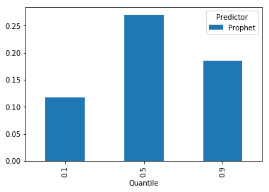

```python
pd.concat(metrics) \
        .pivot(index='Quantile', columns='Predictor', values='LossValue').plot.bar();
```

# Step 5. Creating a Forecast

The `create_forecast` method uses the predictor to create a forecast. In the response, you will get the Amazon Resource Name (ARN) of the forecast. You use this ARN to retrieve and export the forecast.

Now create a forecast using the prophet dataset and the optional predictor if you created one.

```python
forecast_name = f'{project}_prophet'
response = forecast.create_forecast(
    ForecastName=forecast_name,
    PredictorArn=predictor_arn_prophet
)

forecast_arn_prophet = response['ForecastArn']
```

# (OPTIONAL) Create Forecasts For Other Predectors

```python
hint('5')
```

```python
forecast_arn_deep_ar = None
#forecast_name = f'{project}_prophet'
#response = # TODO
#forecast_arn_deep_ar = response['ForecastArn']
```

You can also create a forecast for an additional model if one was trained.

```python
forecast_arn_other = None
#forecast_name = # TODO
#response = # TODO
#forecast_arn_other = response['ForecastArn']
```

Now we need to wait for the forecasts to be finish being created.

```python
wait(lambda: forecast.describe_forecast(ForecastArn=forecast_arn_prophet))
forecast.describe_forecast(ForecastArn=forecast_arn_prophet)

if forecast_arn_deep_ar:
    wait(lambda: forecast.describe_forecast(ForecastArn=forecast_arn_deep_ar))
    forecast.describe_forecast(ForecastArn=forecast_arn_deep_ar)

if forecast_arn_other:
    wait(lambda: forecast.describe_forecast(ForecastArn=forecast_arn_other))
    forecast.describe_forecast(ForecastArn=forecast_arn_other)
```

```
...........................
```

To query the forecasts that have been created, use the following parameters.

- **start-date** and **end-date** – Specifies an optional date range to retrieve the forecast for. If you don't specify these parameters, the operation returns the entire forecast for bike_12.
- **filters** – Specifies the item_id filter to retrieve the sales forecast for bike_12.

Because this is an hourly forecast, the response shows hourly forecast values. In the response, note the following:

- **mean** – For the specific date and time, the mean is the predicted mean bike sales for the item.
- **p90, p50, and p10** – Specify the confidence level that the actual value will be below the listed value at the specified date and time.

For more information about this operation, see [QueryForecast](https://docs.aws.amazon.com/forecast/latest/dg/API_forecastquery_QueryForecast.html).

# Step 6. Querying the Forecasts

```python
item_id = 'bike_12'

response = forecast_query.query_forecast(
    ForecastArn=forecast_arn_prophet,
    Filters={"item_id": item_id}
)
```

The response is a json structure:

```python
print(json.dumps(response))
```

```
{"Forecast": {"Predictions": {"p10": [{"Timestamp": "2012-12-19T00:00:00", "Value": -71.37879943847656}, {"Timestamp": "2012-12-19T01:00:00", "Value": -53.45951843261719}, {"Timestamp": "2012-12-19T02:00:00", "Value": -122.08808898925781}, {"Timestamp": "2012-12-19T03:00:00", "Value": -162.045867919…
```

We will use a utility function already created for you to plot the actual values against the predicted values.

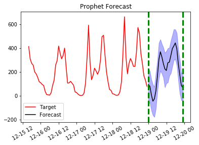

```python
fname = f'../data/bike_target.csv'
actual = load_exact_sol(fname, item_id)

plot_forecasts(response, actual)
plt.title("Prophet Forecast");
```

(OPTIONAL) Now query the forecast for DeepAR and other predictors if they were created, and if you created it, your optional predictor.

```python
hint('6')
```

```python
#response = # TODO DEEPAR
# plot_forecasts(response, actual)
# plt.title("Other Forecast");

#response = # TODO OTHER
# plot_forecasts(response, actual)
# plt.title("Other Forecast");
```

# Step 7. Exporting your Forecasts

```python
name = f'{project}_forecast_export_prophet'
s3_path = f"{s3_data_path}/{name}"

response = forecast.create_forecast_export_job(
    ForecastExportJobName=name,
    ForecastArn=forecast_arn_prophet,
    Destination={
        "S3Config" : {
            "Path": s3_path,
             "RoleArn": role_arn
        }
    }
)

forecast_export_arn_prophet = response['ForecastExportJobArn']
```

(OPTIONAL) Now create your own export job for the deep ar model

```python
hint('7')
```

```python
forecast_export_arn_deep_ar = None

#name = f'{project}_forecast_export_deep_ar_plus'
#s3_path = f"{s3_data_path}/{name}"
#
# response =
#forecast_export_arn_deep_ar = response['ForecastExportJobArn']
```

# Step 8. Cleaning up your Resources

Once we have completed the above steps, we can start to cleanup the resources we created. All delete jobs, except for `delete_dataset_group` are asynchronous, so we have added the helpful `wait_till_delete` function. Resource Limits documented [here](https://docs.aws.amazon.com/forecast/latest/dg/limits.html).

```python
# Delete forecast export for both algorithms
wait_till_delete(lambda: forecast.delete_forecast_export_job(ForecastExportJobArn = forecast_export_arn_prophet))
if forecast_export_arn_deep_ar:
    wait_till_delete(lambda: forecast.delete_forecast_export_job(ForecastExportJobArn = forecast_export_arn_deep_ar))
```

```python
# Delete forecast for both algorithms
wait_till_delete(lambda: forecast.delete_forecast(ForecastArn = forecast_arn_prophet))
if forecast_arn_deep_ar:
    wait_till_delete(lambda: forecast.delete_forecast(ForecastArn = forecast_arn_deep_ar))
if forecast_arn_other:
    wait_till_delete(lambda: forecast.delete_forecast(ForecastExportJobArn = forecast_arn_other))
```

```python
# Delete predictor for both algorithms
wait_till_delete(lambda: forecast.delete_predictor(PredictorArn = predictor_arn_prophet))
if predictor_arn_deep_ar:
    wait_till_delete(lambda: forecast.delete_predictor(PredictorArn = predictor_arn_deep_ar))
if predictor_arn_other:
    wait_till_delete(lambda: forecast.delete_forecast_export_job(ForecastExportJobArn = predictor_arn_other))
```

```python
# Delete the target time series and related time series dataset import jobs
wait_till_delete(lambda: forecast.delete_dataset_import_job(DatasetImportJobArn=target_dataset_import_job_arn))
if related_dataset_import_job_arn:
    wait_till_delete(lambda: forecast.delete_dataset_import_job(DatasetImportJobArn=related_dataset_import_job_arn))
```

```python
# Delete the target time series and related time series datasets
wait_till_delete(lambda: forecast.delete_dataset(DatasetArn=target_dataset_arn))
if related_dataset_arn:
    wait_till_delete(lambda: forecast.delete_dataset(DatasetArn=related_dataset_arn))
```

```python
# Delete dataset group
forecast.delete_dataset_group(DatasetGroupArn=dataset_group_arn)
```